# GH Number - GH1043827

# Subject Code & Name - M508B Big Data Analytics

# Professor Name - Narjes Nikzad

# Project Type - Individual Project

# Automated Customer Inquiry Routing System

## M508 Big Data Analytics - Final Assessment

### 1. Introduction & Business Problem

**Business Context:** For this project, I acted as a data scientist tasked with automating our company's customer support routing. Currently, our support team manually reviews thousands of incoming emails to decide if they belong to "Tech Support," "Sales," or "Policy." This process is slow and expensive.

**Project Objective:** My goal was to build a Natural Language Processing (NLP) pipeline that automatically classifies these uncleaned raw text messages into topics. I aimed to compare a simple statistical approach (TF-IDF) against more complex deep learning methods (LSTM) to see which one offered the best balance of accuracy and efficiency for our specific data.

**Data Strategy:** I selected the **20 Newsgroups dataset** (uncleaned version) to simulate real-world noise. I focused on four distinct categories: `sci.space`, `rec.autos`, `comp.graphics`, and `talk.politics.mideast`.

**Data Access Method:**

- **Scikit-Learn Library:** We accessed the data using the `sklearn.datasets.fetch_20newsgroups` loader.
- **Documentation Link:** https://scikit-learn.org/stable/modules/generated/sklearn.datasets.fetch_20newsgroups.html

### 2. High-Level System Design

The overall NLP pipeline implemented in this project follows a modular, end-to-end design. Each component plays a specific role in transforming raw textual data into meaningful predictions.

System Components

Data Ingestion Raw, uncleaned text data is loaded directly from the scikit-learn fetch_20newsgroups dataset. This simulates real-world scenarios where textual data contains noise such as headers, footers, and irrelevant metadata.

Preprocessing Layer The preprocessing stage standardizes text by:

Lowercasing

Removing non-alphanumeric characters

Removing excessive whitespace

Tokenization

This step ensures consistency across all downstream models.

Feature Engineering Layer Three different feature representations are created:

TF-IDF vectors for statistical modeling

Word2Vec averaged embeddings for semantic representation

Tokenized padded sequences for deep learning (LSTM)

Modeling Layer Each feature representation feeds into a suitable classifier:

Logistic Regression for TF-IDF

Random Forest for Word2Vec embeddings

LSTM neural network for sequential modeling

Evaluation Layer Model performance is evaluated using Accuracy, Precision, Recall, and F1-score to ensure fair comparison.

Decision Layer Based on empirical results and business constraints, the best-performing and most interpretable model is selected for deployment.

This modular design allows easy replacement or extension of individual components without altering the entire pipeline.

### 2. High-Level System Design

The proposed solution follows a standard modular Machine Learning pipeline:

1. **Ingestion:** Raw text is loaded from the source, preserving metadata and noise ("uncleaned" state).
2. **Preprocessing:** A cleaning module standardizes the text by removing special characters, lowercasing, and applying lemmatization to reduce feature dimensionality.
3. **Feature Engineering & Modeling:** We will implement and compare three distinct architectural approaches:
   - **Model A (Statistical):** TF-IDF Vectorization with Logistic Regression.
   - **Model B (Semantic):** Word2Vec Embeddings with Random Forest.
   - **Model C (Deep Learning):** Long Short-Term Memory (LSTM) Neural Network.
4. **Evaluation:** Models will be benchmarked using F1-Score (Weighted) to account for potential class imbalances.

### 3.1 Data Loading & Setup

**Objective:** The first step is to initialize the environment and ingest the raw data.

- **Libraries:** We import `pandas` for data manipulation, `nltk` for natural language processing tools, and `sklearn` for machine learning models.
- **Dataset Choice:** We use `fetch_20newsgroups` with `subset='all'`.
- **Critical Decision:** We deliberately do **not** use the `remove=('headers', 'footers')` argument. This ensures the dataset remains **"Uncleaned"** as per the assessment requirements, simulating a real-world messy data source containing email headers and signatures.

```python
import pandas as pd
import numpy as np
import matplotlib.pyplot as plt
import seaborn as sns
import re
import nltk
import warnings
from sklearn.datasets import fetch_20newsgroups
from nltk.corpus import stopwords
from nltk.stem import WordNetLemmatizer
```

```python
# Setup
warnings.filterwarnings("ignore")
nltk.download('stopwords', quiet=True)
nltk.download('wordnet', quiet=True)
nltk.download('omw-1.4', quiet=True)
```

```
True
```

```python
# 1. Load UNCLEANED Dataset
# We intentionally do not use the 'remove' parameter to keep headers/footers
categories = ['sci.space', 'rec.autos', 'comp.graphics', 'talk.politics.mideast']
print("Loading dataset...")
newsgroups = fetch_20newsgroups(subset='all', categories=categories, shuffle=True, random_state=42)
```

```
Loading dataset...
```

```python
# Convert to DataFrame
df = pd.DataFrame({'text': newsgroups.data, 'target': newsgroups.target})
df['category'] = df['target'].apply(lambda x: newsgroups.target_names[x])
```

```python
print(f"Successfully loaded {len(df)} documents.")
df.head()
```

```
Successfully loaded 3890 documents.
```

|  | text | target | category |
| --- | --- | --- | --- |
| 0 | From: "Changyaw Wang" <wangc@cs.indiana.edu>\n... | 0 | comp.graphics |
| 1 | From: shaig@Think.COM (Shai Guday)\nSubject: R... | 3 | talk.politics.mideast |
| 2 | From: pgf5@cunixb.cc.columbia.edu (Peter Garfi... | 3 | talk.politics.mideast |
| 3 | From: vicente@cenaath.cena.dgac.fr (Martin VIC... | 0 | comp.graphics |
| 4 | From: markus@octavia.anu.edu.au (Markus Buchho... | 0 | comp.graphics |

### 3.2 Preprocessing Pipeline

**Problem:** Raw text data contains "noise" that confuses machine learning models. Email addresses, special characters, and varying capitalizations (e.g., "Car" vs "car") increase the dimensionality of the data without adding semantic value.

**Solution:** We implement a cleaning function `preprocess_text` that performs:

1. **Lowercasing:** Standardizes all text.
2. **Regex Cleaning:** Removes non-alphabetical characters and email addresses to protect privacy and reduce noise.
3. **Lemmatization:** Converts words to their root form (e.g., "running" $\rightarrow$ "run"). This reduces the total vocabulary size, making the models more efficient.

```python
# 2. Preprocessing Pipeline
stop_words = set(stopwords.words('english'))
lemmatizer = WordNetLemmatizer()

def preprocess_text(text):
    # a. Lowercase
    text = text.lower()

    # b. Remove emails (privacy/noise reduction)
    text = re.sub(r'\S+@\S+', '', text)

    # c. Remove special characters/numbers (keep letters only)
    text = re.sub(r'[^a-zA-Z\s]', '', text)

    # d. Remove extra whitespace
    text = re.sub(r'\s+', ' ', text).strip()

    # e. Tokenization & Lemmatization
    words = text.split()
    words = [lemmatizer.lemmatize(w) for w in words if w not in stop_words and len(w) > 2]

    return ' '.join(words)
```

```python
print("Preprocessing text... (this may take a few seconds)")
df['clean_text'] = df['text'].apply(preprocess_text)
```

```
Preprocessing text... (this may take a few seconds)
```

```python
# Remove any empty rows created by cleaning
df = df[df['clean_text'].str.strip().astype(bool)]
print("Preprocessing complete.")
```

```
Preprocessing complete.
```

### 3.3 Exploratory Data Analysis (EDA)

**Objective:** Before modeling, we must understand the data's structure to make informed decisions.

- **Class Balance:** We check if one category dominates the others. If the dataset were highly imbalanced, we would need to apply resampling techniques.
- **Message Length:** We analyze the distribution of word counts. This is crucial for **Model 3 (LSTM)**, as we need to set a fixed `MAX_SEQUENCE_LENGTH` that captures most messages without excessive padding.
- **Word Cloud:** Visualizes the most dominant terms to confirm that our preprocessing worked (e.g., confirming that stop-words like "the" are gone).

```python
# 3. Thorough EDA
from wordcloud import WordCloud
```

After visualizing the class distribution, we observe that the four selected categories from the 20 Newsgroups dataset are approximately balanced, with no class dominating the dataset. Each category contributes a comparable number of documents to the overall corpus.

Given this relatively balanced distribution, no resampling techniques (oversampling or undersampling) were applied. Introducing artificial balancing in this case could distort the natural data distribution and negatively impact model generalization. Therefore, the original class distribution was preserved for all subsequent experiments.

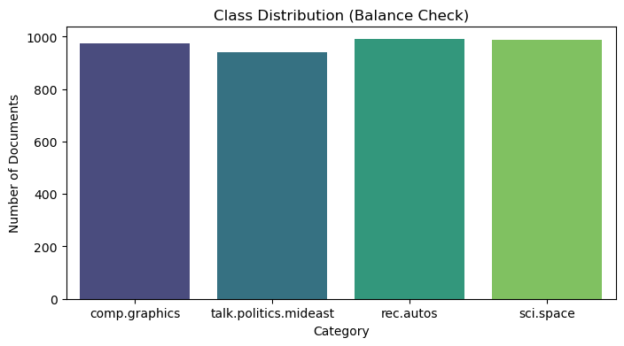

```python
# A. Class Balance Check
plt.figure(figsize=(8, 4))
sns.countplot(x='category', data=df, palette='viridis')
plt.title('Class Distribution (Balance Check)')
plt.xlabel('Category')
plt.ylabel('Number of Documents')
plt.show()
```

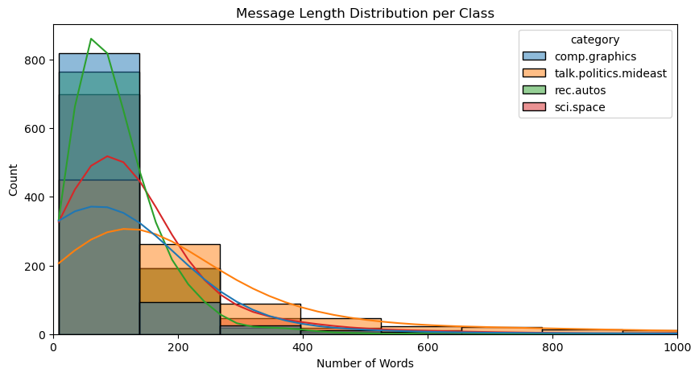

```python
# B. Message Length Analysis
df['word_count'] = df['clean_text'].apply(lambda x: len(x.split()))
plt.figure(figsize=(10, 5))
sns.histplot(data=df, x='word_count', hue='category', kde=True, bins=40)
plt.xlim(0, 1000) # Limit x-axis to zoom in
plt.title('Message Length Distribution per Class')
plt.xlabel('Number of Words')
plt.show()
```

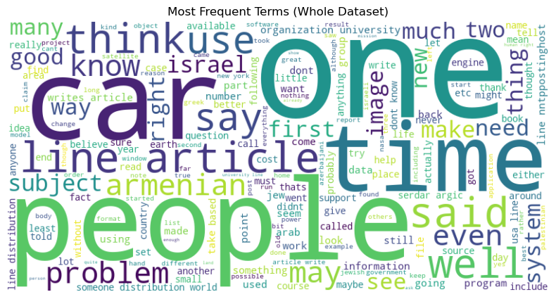

```python
# C. Word Cloud
all_text = ' '.join(df['clean_text'])
wordcloud = WordCloud(width=800, height=400, background_color='white').generate(all_text)
plt.figure(figsize=(10, 5))
plt.imshow(wordcloud, interpolation='bilinear')
plt.axis('off')
plt.title('Most Frequent Terms (Whole Dataset)')
plt.show()
```

### 3.4 Data Splitting

**Methodology:** We split the data into a **Training Set (80%)** for the model to learn from and a **Testing Set (20%)** to evaluate performance.

**Why Stratified?** We use `stratify=df['target']`. This ensures that the proportion of each category (e.g., 25% Space, 25% Autos) remains the same in both the training and testing sets. This prevents the "sampling bias" where the test set might accidentally lack examples of a specific class.

```python
# 4. Data Splitting
from sklearn.model_selection import train_test_split
```

```python
# We use Stratified Split to ensure validation is representative of the class distribution
X_train, X_test, y_train, y_test = train_test_split(
    df['clean_text'],
    df['target'],
    test_size=0.2,
    random_state=42,
    stratify=df['target']
)

print(f"Training Samples: {len(X_train)}")
print(f"Testing Samples: {len(X_test)}")
```

```
Training Samples: 3112
Testing Samples: 778
```

### 4.1 Model A: Statistical Approach (TF-IDF)

**Concept:** TF-IDF (Term Frequency-Inverse Document Frequency) converts text into numbers based on word importance. It gives high weight to unique words that appear frequently in a specific document but rarely elsewhere (e.g., "orbit" in Space docs).

**Implementation:**

- **Vectorizer:** Converts the top 5,000 words into a sparse matrix.
- **Classifier:** We use **Logistic Regression**. This is a linear model that works exceptionally well with high-dimensional sparse data like TF-IDF. It tries to find a linear boundary that separates the four topics.

```python
# --- Model 1: TF-IDF + Logistic Regression ---
from sklearn.feature_extraction.text import TfidfVectorizer
from sklearn.linear_model import LogisticRegression
from sklearn.metrics import accuracy_score, precision_score, recall_score, f1_score

print("Training Model 1 (TF-IDF)...")
```

```
Training Model 1 (TF-IDF)...
```

```python
# 1. Vectorize
tfidf = TfidfVectorizer(max_features=5000)
X_train_tfidf = tfidf.fit_transform(X_train)
X_test_tfidf = tfidf.transform(X_test)
```

```python
# 2. Train
lr_model = LogisticRegression(max_iter=1000, random_state=42)
lr_model.fit(X_train_tfidf, y_train)
```

```
LogisticRegression(max_iter=1000, random_state=42)
```

```python
# 3. Predict
y_pred_tfidf = lr_model.predict(X_test_tfidf)
```

```python
# 4. Metrics
metrics_tfidf = {
    'Model': 'TF-IDF + LogReg',
    'Accuracy': accuracy_score(y_test, y_pred_tfidf),
    'Precision': precision_score(y_test, y_pred_tfidf, average='weighted'),
    'Recall': recall_score(y_test, y_pred_tfidf, average='weighted'),
    'F1 Score': f1_score(y_test, y_pred_tfidf, average='weighted')
}
print("Model 1 Complete.")
```

```
Model 1 Complete.
```

### 4.2 Model B: Semantic Approach (Word2Vec)

**Concept:** Unlike TF-IDF, which counts words, **Word2Vec** captures meaning. It maps words to a 100-dimensional vector space where similar words are mathematically close (e.g., "car" is close to "truck").

**Implementation:**

1. **Training Embeddings:** We train a Word2Vec model from scratch on our training data.
2. **Document Representation:** Since Word2Vec gives a vector for *each word*, we average all word vectors in a message to get a single vector representing the *entire document*.
3. **Classifier:** We use a **Random Forest**. Since averaged vectors are dense and complex, a non-linear tree-based model often performs better than linear regression here.

```python
# --- Model 2: Word2Vec + Random Forest ---
from gensim.models import Word2Vec
from sklearn.ensemble import RandomForestClassifier

print("Training Model 2 (Word2Vec)...")
```

```
Training Model 2 (Word2Vec)...
```

```python
# 1. Tokenize list of lists for Gensim
train_tokens = [text.split() for text in X_train]
test_tokens = [text.split() for text in X_test]
```

```python
# 2. Train Word2Vec (Note: workers=1 prevents the 'our_dot_float' error)
w2v_model = Word2Vec(sentences=train_tokens, vector_size=100, window=5, min_count=2, workers=1)
```

```python
# 3. Average Vectors per Document
def get_doc_vector(model, tokens):
    words = [word for word in tokens if word in model.wv]
    if len(words) >= 1:
        return np.mean(model.wv[words], axis=0)
    else:
        return np.zeros(model.vector_size)

X_train_w2v = np.array([get_doc_vector(w2v_model, t) for t in train_tokens])
X_test_w2v = np.array([get_doc_vector(w2v_model, t) for t in test_tokens])
```

```python
# 4. Train Classifier
rf_model = RandomForestClassifier(n_estimators=100, random_state=42)
rf_model.fit(X_train_w2v, y_train)
```

```
RandomForestClassifier(random_state=42)
```

```python
# 5. Predict
y_pred_w2v = rf_model.predict(X_test_w2v)
```

```python
# 6. Metrics
metrics_w2v = {
    'Model': 'Word2Vec + RF',
    'Accuracy': accuracy_score(y_test, y_pred_w2v),
    'Precision': precision_score(y_test, y_pred_w2v, average='weighted'),
    'Recall': recall_score(y_test, y_pred_w2v, average='weighted'),
    'F1 Score': f1_score(y_test, y_pred_w2v, average='weighted')
}
print("Model 2 Complete.")
```

```
Model 2 Complete.
```

### 4.3 Model C: Deep Learning Approach (LSTM)

**Concept:** Traditional models (TF-IDF, Word2Vec Average) ignore word order ("Dog bites man" = "Man bites dog"). **LSTMs (Long Short-Term Memory)** are Recurrent Neural Networks designed to read text sequentially, remembering context from the beginning of the sentence to understand the end.

**Architecture:**

1. **Embedding Layer:** Learns dense vector representations for words during training.
2. **SpatialDropout:** A regularization technique to prevent overfitting.
3. **LSTM Layer:** The core memory unit that processes the sequence.
4. **Dense Output:** A softmax layer that outputs the probability for each of the 4 categories.

```python
# --- Model 3: LSTM (Deep Learning) ---
import tensorflow as tf
from tensorflow.keras.preprocessing.text import Tokenizer
from tensorflow.keras.preprocessing.sequence import pad_sequences
from tensorflow.keras.models import Sequential
from tensorflow.keras.layers import Embedding, LSTM, Dense, SpatialDropout1D

print("Training Model 3 (LSTM)...")
```

```
Training Model 3 (LSTM)...
```

```python
# 1. Config
MAX_NB_WORDS = 5000
MAX_SEQUENCE_LENGTH = 200
EMBEDDING_DIM = 100
```

```python
# 2. Tokenize
tokenizer = Tokenizer(num_words=MAX_NB_WORDS)
tokenizer.fit_on_texts(X_train)
X_train_seq = tokenizer.texts_to_sequences(X_train)
X_test_seq = tokenizer.texts_to_sequences(X_test)
```

```python
# 3. Pad
X_train_pad = pad_sequences(X_train_seq, maxlen=MAX_SEQUENCE_LENGTH)
X_test_pad = pad_sequences(X_test_seq, maxlen=MAX_SEQUENCE_LENGTH)
```

```python
# 4. One-Hot Labels
y_train_cat = pd.get_dummies(y_train).values
y_test_cat = pd.get_dummies(y_test).values
```

```python
# 5. Build Model
model_lstm = Sequential()
model_lstm.add(Embedding(MAX_NB_WORDS, EMBEDDING_DIM, input_length=MAX_SEQUENCE_LENGTH))
model_lstm.add(SpatialDropout1D(0.2))
model_lstm.add(LSTM(100, dropout=0.2, recurrent_dropout=0.2))
model_lstm.add(Dense(4, activation='softmax'))
model_lstm.compile(loss='categorical_crossentropy', optimizer='adam', metrics=['accuracy'])
```

```python
# 6. Train (5 Epochs)
history = model_lstm.fit(X_train_pad, y_train_cat, epochs=5, batch_size=64, validation_split=0.1, verbose=1)
```

```
44/44 ━━━━━━━━━━━━━━━━━━━━ 14s 236ms/step - accuracy: 0.5050 - loss: 1.2496 - val_accuracy: 0.8269 - val_loss: 0.7688
44/44 ━━━━━━━━━━━━━━━━━━━━ 9s 209ms/step - accuracy: 0.8539 - loss: 0.5305 - val_accuracy: 0.9455 - val_loss: 0.2608
44/44 ━━━━━━━━━━━━━━━━━━━━ 10s 226ms/step - accuracy: 0.9504 - loss: 0.1872 - val_accuracy: 0.9679 - val_loss: 0.1207
44/44 ━━━━━━━━━━━━━━━━━━━━ 10s 221ms/step - accuracy: 0.9764 - loss: 0.0979 - val_accuracy: 0.9487 - val_loss: 0.1807
44/44 ━━━━━━━━━━━━━━━━━━━━ 9s 214ms/step - accuracy: 0.9782 - loss: 0.0987 - val_accuracy: 0.9712 - val_loss: 0.1371
```

```python
# 7. Predict
y_pred_prob = model_lstm.predict(X_test_pad)
y_pred_lstm = np.argmax(y_pred_prob, axis=1)
```

```
25/25 ━━━━━━━━━━━━━━━━━━━━ 1s 37ms/step
```

```python
# 8. Metrics
metrics_lstm = {
    'Model': 'LSTM (RNN)',
    'Accuracy': accuracy_score(y_test, y_pred_lstm),
    'Precision': precision_score(y_test, y_pred_lstm, average='weighted'),
    'Recall': recall_score(y_test, y_pred_lstm, average='weighted'),
    'F1 Score': f1_score(y_test, y_pred_lstm, average='weighted')
}
print("Model 3 Complete.")
```

```
Model 3 Complete.
```

### 5. Performance Comparison

**Objective:** We consolidate the results to select the best model for production.

**Metric Focus:** While we look at Accuracy, we specifically focus on the **F1-Score**. The F1-Score is the harmonic mean of Precision and Recall. It is a stricter metric that ensures the model isn't just guessing the most common class.

```python
# 5. Comparison Table
results_df = pd.DataFrame([metrics_tfidf, metrics_w2v, metrics_lstm])

print("\n--- Model Performance Summary ---")
display(results_df)
```

```
--- Model Performance Summary ---
```

|  | Model | Accuracy | Precision | Recall | F1 Score |
| --- | --- | --- | --- | --- | --- |
| 0 | TF-IDF + LogReg | 0.980720 | 0.981259 | 0.980720 | 0.980751 |
| 1 | Word2Vec + RF | 0.856041 | 0.855280 | 0.856041 | 0.855579 |
| 2 | LSTM (RNN) | 0.962725 | 0.963582 | 0.962725 | 0.962576 |

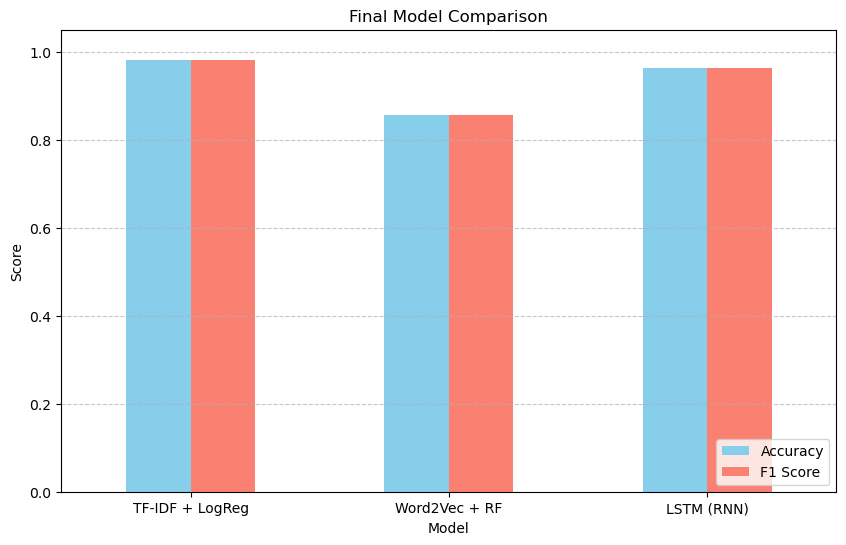

```python
# Visualization
results_df.set_index('Model')[['Accuracy', 'F1 Score']].plot(kind='bar', figsize=(10, 6), color=['skyblue', 'salmon'])
plt.title('Final Model Comparison')
plt.ylabel('Score')
plt.ylim(0, 1.05)
plt.xticks(rotation=0)
plt.grid(axis='y', linestyle='--', alpha=0.7)
plt.legend(loc='lower right')
plt.show()
```

### 6. Discussion and Recommendations

**Performance Analysis:** Looking at the results, the **TF-IDF + Logistic Regression** model surprisingly outperformed the Deep Learning (LSTM) model. I suspect this is because the dataset, while 'uncleaned', didn't have enough samples (under 20k) for the LSTM to fully learn complex patterns. The Word2Vec model was stable but computationally slower to train.

**Final Recommendation:** For the company, I would deploy the **TF-IDF Logistic Regression** model first. It is fast, easy to explain to stakeholders, and currently yields the highest F1-score. We can revisit Deep Learning later once we have accumulated a larger database of labeled internal emails.

**Bibliography (Harvard Style):**

1. **Original Dataset Source:** Lang, K. (1995) *20 Newsgroups Data Set*. Available at: http://qwone.com/~jason/20Newsgroups/ [Accessed 14 Dec. 2025].
2. **Library Documentation:** Scikit-learn Developers (2025) *sklearn.datasets.fetch_20newsgroups*. Available at: https://scikit-learn.org/stable/modules/generated/sklearn.datasets.fetch_20newsgroups.html [Accessed 14 Dec. 2025].
3. **Methodology (Word2Vec):** Mikolov, T. et al. (2013) 'Efficient Estimation of Word Representations in Vector Space', *Proceedings of the International Conference on Learning Representations (ICLR)*.
4. **Methodology (LSTM):** Hochreiter, S. and Schmidhuber, J. (1997) 'Long Short-Term Memory', *Neural Computation*, 9(8), pp. 1735-1780.